# HW 12

Jeff Gould

11/19/2020

## 1) The file contains $50$ iid samples, $\hat{X}_1, \hat{X}_2,\dots, \hat{X}_{50}$, from a one-dimensional random variable $X$.. Assume that $X \sim \mathcal{N}(\mu, \sigma^2)$ where $\sigma^2$ is known with $\sigma^2 = 1$. Our goal is to estimate $\mu$. Let $\bar{x}$ be the sample mean and $N=50$.

### a) Show that the maximum likelihood estimate (MLE) of $\mu$ is given by the sample mean $\bar{x}$.

$\ell(\mu) = P(\hat{X}|\mu) = \sum_{i=1}^{N=50} \log P(\hat{X}_i | \mu) = \sum_{i=1}^{N=50} \log\left(\frac{1}{\sqrt{2\pi\sigma^2}}e^{-(\hat{X}_i - \mu)^2/(2\sigma^2)} \right)$

$= \sum_{i=1}^{N=50} \log\left(\frac{1}{\sqrt{2\pi}}e^{-(\hat{X}_i - \mu)^2/2} \right) = N \log\left(\frac{1}{\sqrt{2\pi}} \right) - \sum_{i=1}^{N=50} (\hat{X}_i - \mu)^2/2$

$0 = \frac{d\ell(\mu)}{d \mu} = \sum_{i=1}^{N=50} 2(\hat{X}_i - \mu) / 2 = \sum_{i=1}^{N=50} (\hat{X}_i - \mu) = \sum_{i=1}^{N=50} \hat{X}_i - N\mu \Rightarrow$

$0 = \sum_{i=1}^{N=50} \hat{X}_i - N\mu \rightarrow N\mu = \sum_{i=1}^{N=50} \hat{X}_i \rightarrow \mu = \frac{1}{N} \sum_{i=1}^{N=50} \hat{X}_i = \bar{x}$

### b) Taking a Bayesian approach, assume a normal prior on $\mu$, $\mu \sim \mathcal{N}(0, \beta^2)$ with $\beta = 10$. Let $f(\mu)$ be the pdf of the prior. Let $p(\mu)$ be the posterior. Show $p(\mu) = \frac{1}{Z} P(\hat{X}_1, \hat{X}_2,\dots, \hat{X}_{50} \ | \ \mu) f(\mu)$

$\mu \sim \mathcal{N}(0, \beta^2) \rightarrow f(\mu) \sim \frac{1}{\sqrt{2\pi\beta^2}}e^{-(\mu^2)/(2\beta^2)}$

$p(\mu) = P(\mu | \hat{X}_1, \hat{X}_2 \dots \hat{X}_{50}) = \frac{P(\mu, \hat{X}_1, \hat{X}_2 \dots \hat{X}_{50})}{P(\hat{X}_1, \hat{X}_2 \dots \hat{X}_{50})} = \frac{P(\hat{X}_1, \hat{X}_2 \dots \hat{X}_{50} | \mu) f(\mu)}{P(\hat{X}_1, \hat{X}_2 \dots \hat{X}_{50})}$

each $X_i \sim \mathcal{N}(\mu, 1^2)$, iid. So $P(\hat{X}_1, \hat{X}_2 \dots \hat{X}_{50}) = \int_{-\infty}^{\infty}P(\hat{X}_1, \hat{X}_2 \dots \hat{X}_{50}|\mu)f(\mu)d\mu = Z$

$\frac{P(\hat{X}_1, \hat{X}_2 \dots \hat{X}_{50} | \mu) P(\mu)}{P(\hat{X}_1, \hat{X}_2 \dots \hat{X}_{50})} = \frac{1}{Z} P(\hat{X}_1, \hat{X}_2 \dots \hat{X}_{50} | \mu) f(\mu)$

$P(\hat{X}_1, \hat{X}_2 \dots \hat{X}_{50} | \mu) P(\mu) = \left[\prod_{i=1}^N \frac{1}{\sqrt{2\pi\sigma^2}} \exp[-(x_i - \mu)^2/(2\sigma^2) \right] \frac{1}{\sqrt{2\pi\beta^2}}\exp[-\mu^2 / (2\beta^2)] = \frac{1}{(2\pi)^{(n+1)/2}\sqrt{\beta^2\sigma^{2n}}} \exp[\frac{-\mu^2}{2\beta^2} - \sum_{i=1}^N\frac{x_i^2 - 2\mu x_i + \mu^2}{2\sigma^2}] \propto$

$\exp \left[\frac{-\mu^2(\sigma^2 + N\beta^2) + 2\mu(\sum \beta^2x_i) - \sum(\beta^2 x_i^2)}{2\sigma^2\beta^2} \right] = \exp\left[\frac{-\mu^2 + 2\mu \frac{\sum \beta^2x_i}{\sigma^2 + N \beta^2} - \left(\frac{\sum \beta^2 x_i}{\sigma^2 + N \beta^2}\right)^2}{2 \frac{\beta^2 \sigma^2}{\sigma^2 + N \beta^2}} \right] \cdot \exp\left[\frac{-\sum \beta^2 x_i^2}{2\sigma^2 \beta^2} \right] \propto$

$\exp\left[- \frac{\left(\mu - \frac{\sum \beta^2 x_i}{\sigma^2 + N \beta^2}\right)^2}{2 \frac{\beta^2\sigma^2}{\sigma^2 + N \beta^2}} \right]$

$\frac{\beta^2 \sum x_i}{\sigma^2 + N\beta^2} = \frac{\frac{1}{n}\sum x_i}{\frac{\sigma^2}{N\beta^2} + 1} = \frac{\bar{x}}{1 + \frac{\sigma^2}{N\beta^2}}$

$\exp\left[- \frac{\left(\mu - \frac{\sum \beta^2 x_i}{\sigma^2 + N \beta^2}\right)^2}{2 \frac{\beta^2\sigma^2}{\sigma^2 + N \beta^2}} \right] = \exp\left[\frac{\left(\mu - \frac{\bar{x}}{1 + \sigma^2/(N\beta^2)} \right)^2}{2 \frac{\beta^2\sigma^2}{\sigma^2 + N \beta^2}} \right] \Rightarrow$

$p(\mu) \sim \mathcal{N}(\frac{\bar{x}}{1 + \sigma^2/(N\beta^2)}, \frac{\beta^2\sigma^2}{\sigma^2 + N \beta^2})$

[figure not shown]

```r
X <- read.delim("HW12_problem1.txt")
N <- nrow(X)
sigma <- 1
beta <- 10
x_bar <-- mean(X$x)

mu_post <- x_bar / (1 + (sigma / (beta * N)))
var_post <- (sigma * beta) / (N * beta + sigma)

ggplot(data = data.frame(x = c(6.5, 8.5)), aes(x)) +
  stat_function(fun = dnorm,  args = list(mean = mu_post, sd = sqrt(var_post))) +
  scale_y_continuous(breaks = NULL) +
  theme_bw() +
  labs(y = "")
```

### c)

$$f(\mu) = \bigg\{
\begin{array}{cc}
\frac{1}{10} & \text{if } x \in [5,7] \\
4 & \text{if } x \in [9,9.2] \\
0 & \text{otherwise}
\end{array}$$

$\frac{P(X_1, \dots ,X_{50} | \mu)P(\mu)}{P(X_1, \dots, X_{50})}$

$Z = P(X_1, \dots, X_{50}) = \int_5^7 P(X_1, \dots , X_{50} | \mu)f(\mu)d\mu + \int_9^{9.2} P(X_1, \dots , X_{50} | \mu)f(\mu)d\mu = \int_5^7 P(X_1, \dots , X_{50} | \mu)\frac{1}{10}d\mu + \int_9^{9.2} P(X_1, \dots , X_{50} | \mu)(4)d\mu = \int_5^7 \prod_{i=1}^{50} \frac{1}{\sqrt{2\pi}}\exp(-(x_i - \mu)^2 / 2)\frac{1}{10}d\mu + \int_9^{9.2} \prod_{i=1}^{50} \frac{1}{\sqrt{2\pi}}\exp(-(x_i - \mu)^2 / 2)(4)d\mu$

$\frac{P(X_1, \dots ,X_{50} | \mu)P(\mu)}{P(X_1, \dots, X_{50})} = \frac{\left(\prod_{i=1}^{50} \frac{1}{\sqrt{2\pi}} \exp(-(x_i - \mu)^2 / 2)\right)f(\mu)}{Z}$

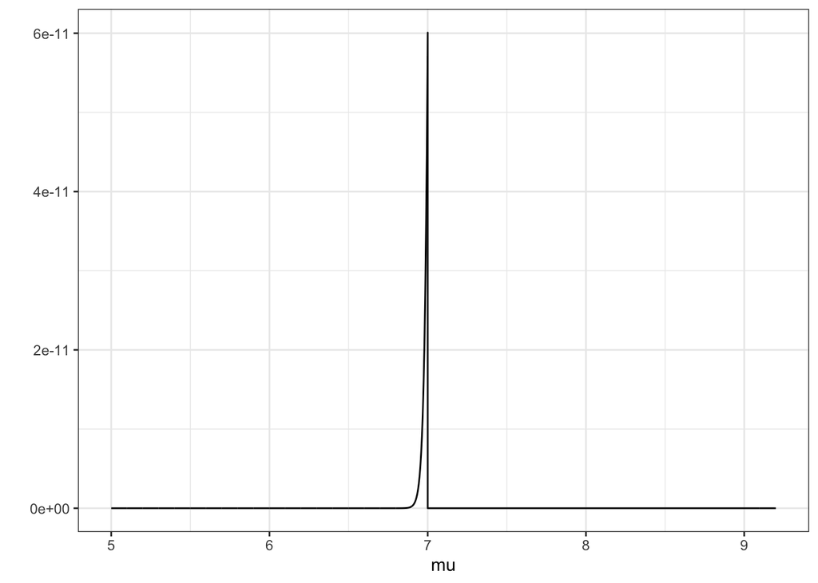

```r
x <- X$x
integrand <- function(mu){
  return(prod(1 / sqrt(2 * pi) * exp(-(x - mu)^2 / 2)))
}
#integrand(5)

i1 <- integrate(Vectorize(integrand), lower = 5, upper = 7)
i2 <- integrate(Vectorize(integrand), lower = 9, upper = 9.2)
Z <- (1/(10)) * i1$value + 4 * i2$value

mu_vec <- seq(5, 7, 0.001)
fff <- function(mu){(1 / (2*pi)^25) * exp(-sum((x - mu)^2)) / 2 * 1/10}
mu_dens1 <- sapply(mu_vec, fff) / Z

mu_vec <- seq(9, 9.2, 0.001)
fff <- function(mu){(1 / (2*pi)^25) * exp(-sum((x - mu)^2)) / 2 * 4}
mu_dens2 <- sapply(mu_vec, fff) / Z

pd <- data.frame(mu = c(seq(5, 7, 0.001),7.000001,8.999999, seq(9, 9.2, 0.001)),
                 probs = c(mu_dens1,0,0, mu_dens2))

ggplot(pd, aes(x = mu, y = probs)) + geom_line() + theme_bw() +
  #scale_y_continuous(breaks = NULL) +
  theme_bw() +
  labs(y = "")
```

```r
# innn <- function(mu){1/(sqrt(2*pi)) * exp(-(a - mu)^2 / 2) }
#
# P <- 1
# for(i in 1:50){
#   a <- x[i]
#   int1 <- integrate(innn, 5, 7)
#   int2 <- integrate(innn, 9, 9.2)
#   pr <- 0.1 * int1$value + 4 * int2$value
#
#   P <- P * pr
#
# }
# P / Z
# integrate(innn, 5, 7)
#
# density <- function(mu){
#   p <- 1
#   for(q in c(0.1, 4))
#   num <- (1/10 * as.numeric(x >= 5 & x <= 7) + 4 * as.numeric(x >= 9 & x <= 9.2)) * exp(-(x - mu)^2 / 2)
#   return(p / Z)
# }
# density(7)
#
# out <- sapply(seq(6, 10, 0.001), density)
#
# ggplot(data = data.frame(x = c(6.5, 8.5)), aes(x)) +
#   stat_function(fun = density) +
#   scale_y_continuous(breaks = NULL) +
#   theme_bw() +
#   labs(y = "")
#
#
```

Using a uniform prior, especially one that has bounds so that it takes a 0 value in the range of the data, does not seem useful. Because $posterior \propto likelihood \times prior$, but the $prior$ is just a constant under a uniform prior, or in this case a piecewise uniform prior. So if the $prior$ is a constant, then $posterior \propto likelihood$. We also we have zero mass between $(7,9)$, even though thats where a lot of the data lives

## 2

### a)

$P(X=x, Y=y, Z=z) =\alpha \exp[\eta_1x + \eta_2y + \eta_3z - w_{12} xy - w_{13} xz]$

The clicks are $(X,Y)$ and $(X,Z)$, since we do not have an edge between $Y$ and $Z$

More rigorously:

Let $\psi_1(x,y) = \exp[\frac{\eta_1}{2}x + \eta_2y - w_{12}xy]$, and let $\psi_2(x,z) = \exp[\frac{\eta_1}{2}x + \eta_3 z - w_{13}xz]$

Then $\alpha \psi_1(x,y) \psi_2(x,z) = \alpha \exp[\frac{\eta_1}{2}x + \eta_2y - w_{12}xy]\exp[\frac{\eta_1}{2}x + \eta_3 z - w_{13}xz] = \alpha \exp[\eta_1x + \eta_2y + \eta_3z - w_{12} xy - w_{13} xz] = P(X=x, Y=y, Z=z)$

$Y \perp Z | X$:

$P(Y | X = x_j) = \alpha \sum_{z\in\{-1, 1\}} \psi_1(Y, x_j) \psi_2(x_j, z) = \alpha \psi_1(Y, x_j) \sum_{z\in\{-1, 1\}}\psi_2(x_j, z) \Rightarrow$

$P(Y = y_i | X = x) = \frac{\psi_1(x, y_i) \sum_{z \in \{-1,1\}}\psi_2(x, z)}{(\psi_1(x, y_i) + \psi_1(x, y_j)) \sum_{z \in \{-1,1\}}\psi_2(x, z)} = \frac{\psi_1(x, y_i)}{\psi_1(x, y_i) + \psi_1(x, y_j)}$

This is free of $Z$, so clearly $Y$ is not dependent on $Z$ when given $X$

$P(Z = z_k| X = x_j) = \alpha \sum_{y\in\{-1, 1\}} \psi_1(y, x_j) \psi_2(x_j, z_k) = \alpha \psi_2(x_j, z_k) \sum_{y\in\{-1, 1\}}\psi_1(x_j, y)$

So likewise,

$P(Z = y_i | X = x) = \frac{\psi_2(x, z_i) \sum_{y \in \{-1,1\}}\psi_1(x, y)}{(\psi_2(x, z_i) + \psi_2(x, z_j)) \sum_{y \in \{-1,1\}}\psi_1(x, y)} = \frac{\psi_2(x, z_i)}{\psi_2(x, z_i) + \psi_2(x, z_j)}$

And $Z$ is not dependent on $Y$ when given $X$

So $Y \perp Z | X$

### b)

Using the same principle as above, since we have $w_{23} \neq 0$, then we know an edge must exist between $Y$ and $Z$, and thus they are not conditionally indepenedent

$P(X=x, Y=y, Z=z) =\alpha \exp[\eta_1x + \eta_2y + \eta_3z - w_{12} xy - w_{13} xz - w_{23} yz]$

$P(Y = y_i | X) =\alpha \sum_{z \in \{-1,1\}} \exp[\eta_1x + \eta_2y_i + \eta_3z - w_{12} xy_i - w_{13} xz - w_{23} y_iz] = \alpha \sum_{z \in \{-1,1\}} \exp[\eta_2y_i - w_{12}xy_i - w_{23}y_iz] \exp[\eta_1x + \eta_3 z - w_{13} xz]$

And we clearly can’t get a $Y$ term free of $Z$ due to $w_{23}yz$, thus $Y$ will not be conditionally independent of $Z$ when given $X$

Similarly for $Z$:

$P(Z = z_i | X) =\alpha \sum_{y \in \{-1,1\}} \exp[\eta_1x + \eta_2y + \eta_3z_1 - w_{12} xy - w_{13} xz_i - w_{23} yz_i] = \alpha \sum_{y \in \{-1,1\}} \exp[\eta_3z_i - w_{13}xz_i - w_{23}yz_i] \exp[\eta_1x + \eta_2 y - w_{12} xy]$

And we can’t get $Z$ free of $Y$

So even with $X$, $Y$ and $Z$ are not conditionally independent

$P(X=x, Y=y, Z=z) =\alpha \exp[\eta_1x + \eta_2y + \eta_3z - w_{12} xy - w_{13} xz - w_{23} yz - w_{123}xyz]$

$P(Y = y_i | X) =\alpha \sum_{z \in \{-1,1\}} \exp[\eta_1x + \eta_2y_i + \eta_3z - w_{12} xy_i - w_{13} xz - w_{23} y_iz - w_{123}xy_iz] = \alpha \sum_{z \in \{-1,1\}} \exp[\eta_2y_i - w_{12}xy_i - w_{23}y_iz - w_{123}xy_iz] \exp[\eta_1x + \eta_3 z - w_{13} xz]$

$P(Z = z_i | X) =\alpha \sum_{y \in \{-1,1\}} \exp[\eta_1x + \eta_2y + \eta_3z_i - w_{12} xy - w_{13} xz_i - w_{23} yz_i - w_{123}xyz_i] = \alpha \sum_{y \in \{-1,1\}} \exp[\eta_3z_i - w_{13}xz_i - w_{23}yz_i - w_{123}xyz_i] \exp[\eta_1x + \eta_2 y - w_{12} xy]$

### c)

$R(\omega', \omega) = R(\omega, \omega') = 1/3$ for all $\omega$, $\omega'$, since there is a $1/3$ chance of picking the coordinate to flip between eah state. So the MH ratio becomes:

$\frac{P(\omega')}{P(\omega)} = \frac{\alpha\exp(\eta_1x' + \eta_2y' +\eta_3z' - w_{12}x'y' - w_{13}x'z')}{\alpha\exp(\eta_1x + \eta_2y +\eta_3z - w_{12}xy - w_{13}xz)} = \frac{\exp(\eta_1x' + \eta_2y' +\eta_3z' - w_{12}x'y' - w_{13}x'z')}{\exp(\eta_1x + \eta_2y +\eta_3z - w_{12}xy - w_{13}xz)} = \frac{\exp(1/2(x'+y'+z') - x'y' + x'z')}{\exp(1/2(x+y+z) - xy + xz)}$

```r
eta <- 0.5
w_12 <- 1
w_13 <- -1


MH_prob <- function(SS){
  x <- SS[,"X"]
  y <- SS[,"Y"]
  z <- SS[,"Z"]
  exp(eta * x + eta * y + eta * z - w_12 * x * y - w_13 * x * z)
  }

stateSpace <- matrix(data = 1, ncol = 3, dimnames = list(c(), c("X", "Y", "Z")))

SShistory <- stateSpace

set.seed(123)
tictoc::tic()
for (i in 1:2500000) {

  flip <- sample(x = c("X", "Y", "Z"), 1)

  newStateSpace = stateSpace
  newStateSpace[,flip] = -newStateSpace[,flip]



  u <- runif(1)

  if(u < min(1, MH_prob(newStateSpace) / MH_prob(stateSpace))){
    stateSpace <- newStateSpace
  }

  if(i %% 1000 == 0 & i >= 10000){
    #print(i)
    SShistory <- rbind(SShistory, stateSpace)
  }


}
tictoc::toc()
```

```
## 44.512 sec elapsed
```

```r
SShistory <- SShistory[-1, ]
cor(SShistory[,"X"], SShistory[,"Y"])
```

```
## [1] -0.6135023
```